# Data Visualization Lab 1: R Markdown

## Intro

[figure not shown]

*ComputerHope.com*

Let’s look at the “spam” dataset found in the *kernlab* package. [Documentation](https://archive.ics.uci.edu/ml/datasets/spambase) of the dataset tells us that each row in this dataset is an observation of a particular email, classified as either spam or non-spam. Most columns describe frequencies of keywords or characters in that particular email. There are three variables describing sequences of capital letters, and the ‘type’ variable is a factor encoding the response variable.

Here’s a few columns from the head of the dataset:

| make | address | all | num3d | our | over | remove | internet | order | mail | receive | will | people | report | addresses | free | business | email | you | credit | your | font | num000 | money | hp | hpl | george | num650 | lab | labs | … |
| --- | --- | --- | --- | --- | --- | --- | --- | --- | --- | --- | --- | --- | --- | --- | --- | --- | --- | --- | --- | --- | --- | --- | --- | --- | --- | --- | --- | --- | --- | --- |
| 0.00 | 0.64 | 0.64 | 0 | 0.32 | 0.00 | 0.00 | 0.00 | 0.00 | 0.00 | 0.00 | 0.64 | 0.00 | 0.00 | 0.00 | 0.32 | 0.00 | 1.29 | 1.93 | 0.00 | 0.96 | 0 | 0.00 | 0.00 | 0 | 0 | 0 | 0 | 0 | 0 | … |
| 0.21 | 0.28 | 0.50 | 0 | 0.14 | 0.28 | 0.21 | 0.07 | 0.00 | 0.94 | 0.21 | 0.79 | 0.65 | 0.21 | 0.14 | 0.14 | 0.07 | 0.28 | 3.47 | 0.00 | 1.59 | 0 | 0.43 | 0.43 | 0 | 0 | 0 | 0 | 0 | 0 | … |
| 0.06 | 0.00 | 0.71 | 0 | 1.23 | 0.19 | 0.19 | 0.12 | 0.64 | 0.25 | 0.38 | 0.45 | 0.12 | 0.00 | 1.75 | 0.06 | 0.06 | 1.03 | 1.36 | 0.32 | 0.51 | 0 | 1.16 | 0.06 | 0 | 0 | 0 | 0 | 0 | 0 | … |
| 0.00 | 0.00 | 0.00 | 0 | 0.63 | 0.00 | 0.31 | 0.63 | 0.31 | 0.63 | 0.31 | 0.31 | 0.31 | 0.00 | 0.00 | 0.31 | 0.00 | 0.00 | 3.18 | 0.00 | 0.31 | 0 | 0.00 | 0.00 | 0 | 0 | 0 | 0 | 0 | 0 | … |
| 0.00 | 0.00 | 0.00 | 0 | 0.63 | 0.00 | 0.31 | 0.63 | 0.31 | 0.63 | 0.31 | 0.31 | 0.31 | 0.00 | 0.00 | 0.31 | 0.00 | 0.00 | 3.18 | 0.00 | 0.31 | 0 | 0.00 | 0.00 | 0 | 0 | 0 | 0 | 0 | 0 | … |
| 0.00 | 0.00 | 0.00 | 0 | 1.85 | 0.00 | 0.00 | 1.85 | 0.00 | 0.00 | 0.00 | 0.00 | 0.00 | 0.00 | 0.00 | 0.00 | 0.00 | 0.00 | 0.00 | 0.00 | 0.00 | 0 | 0.00 | 0.00 | 0 | 0 | 0 | 0 | 0 | 0 | … |

## Summary of Data

### Type

The distribution of the ‘type’ variable will obviously be useful to examine.

```r
sum.type <- summary(spam$type)
```

```
## nonspam    spam
##    2788    1813
```

We see there are 1813 spam emails out of a total of 4601 emails, or 39.4% spam.

### Differences

The first few observations we looked at in our dataset were all spam, so we can’t tell which variables differ between classifications. Let’s explicitly look at that now.

```r
# Calculate the mean of each column for spam and non-spam groups
dt <- spam %>% group_by(type) %>% summarise_all(mean)

# Subtract the non-spam row from the spam row
# Store the result in a new row showing the difference
diff_row <-
  (dt %>% filter(type == "spam") %>% select(-type)) -
  (dt %>% filter(type == "nonspam") %>% select(-type))

# Create a new 'type' factor level
dt <- dt %>% mutate(type = factor(type, levels = c("nonspam", "spam", "diff")))

# Set the new row's type to "diff"
diff_row["type"] <- "diff"

# Append the new row to our table
dt <- rbind(dt, diff_row)

# Display the table
kable(dt, caption = "Group Means and Differences")
```

Group Means and Differences

| type | make | address | all | num3d | our | over | remove | internet | order | mail | receive | will | people | report | addresses | free | business | email | you | credit | your | font | num000 | money | hp | hpl | george | num650 | lab | … |
| --- | --- | --- | --- | --- | --- | --- | --- | --- | --- | --- | --- | --- | --- | --- | --- | --- | --- | --- | --- | --- | --- | --- | --- | --- | --- | --- | --- | --- | --- | --- |
| nonspam | 0.0734792 | 0.2444656 | 0.2005811 | 0.0008859 | 0.1810402 | 0.0445445 | 0.0093831 | 0.0384146 | 0.0380488 | 0.1671700 | 0.0217109 | 0.5363235 | 0.0616643 | 0.0424032 | 0.0083178 | 0.0735868 | 0.0483465 | 0.0972920 | 1.2703407 | 0.0075789 | 0.4387016 | 0.0452260 | 0.0070875 | 0.0171377 | 0.8954735 | 0.4319943 | 1.2652654 | 0.1938056 | 0.1627941 | … |
| spam | 0.1523387 | 0.1646498 | 0.4037948 | 0.1646718 | 0.5139548 | 0.1748759 | 0.2754054 | 0.2081412 | 0.1700607 | 0.3505074 | 0.1184335 | 0.5499724 | 0.1435466 | 0.0835742 | 0.1120794 | 0.5183618 | 0.2875069 | 0.3192278 | 2.2645394 | 0.2055212 | 1.3803696 | 0.2380364 | 0.2470546 | 0.2128792 | 0.0174793 | 0.0091726 | 0.0015499 | 0.0187976 | 0.0006839 | … |
| diff | 0.0788595 | -0.0798158 | 0.2032138 | 0.1637859 | 0.3329146 | 0.1303314 | 0.2660223 | 0.1697266 | 0.1320119 | 0.1833374 | 0.0967226 | 0.0136489 | 0.0818823 | 0.0411710 | 0.1037616 | 0.4447750 | 0.2391604 | 0.2219358 | 0.9941987 | 0.1979423 | 0.9416680 | 0.1928104 | 0.2399671 | 0.1957415 | -0.8779941 | -0.4228216 | -1.2637155 | -0.1750080 | -0.1621102 | … |

Ok, so let’s choose two variables which have a high magnitude, but on different sides of classification.

### capitalTotal

First let’s examine ‘capitalTotal’, the total number of capital letters in the e-mail. Our differences table tells us that in our sample, spam emails have an average of 309 more capital letters in them than non-spam emails.

```r
sum.capTot <- summary(spam$capitalTotal)
```

```
##    Min. 1st Qu.  Median    Mean 3rd Qu.    Max.
##     1.0    35.0    95.0   283.3   266.0 15841.0
```

That’s a large maximum! And the mean number of capital letters per email, 283, is greater than the 3rd quartile, 266. This must be a skewed distribution.

Since we believe there’s a large difference between capital letters in spam and non-spam emails, let’s visualize the distribution of both groups.

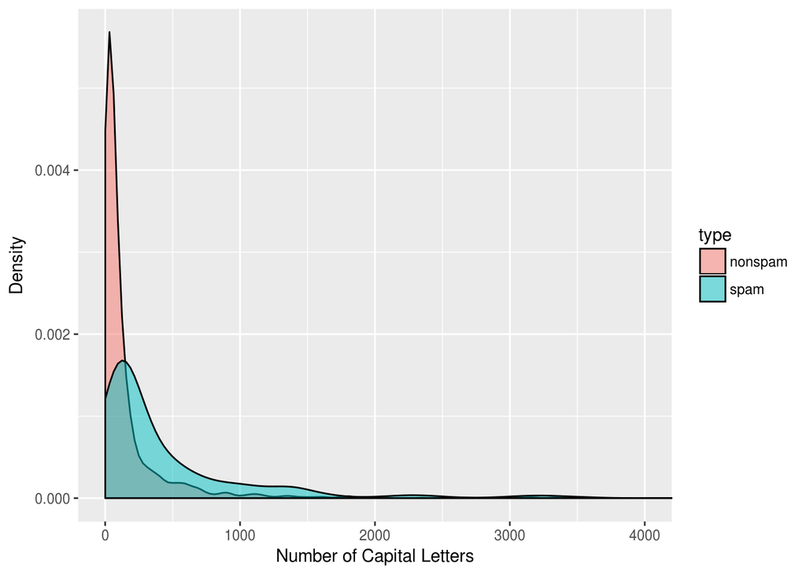

```r
spam %>% ggplot() +
  geom_density(aes(x = capitalTotal, group = type, fill = type), alpha = 0.5, adjust = 2) +
  coord_cartesian(xlim = c(0, 4000)) + # ignore outliers
  xlab("Number of Capital Letters") +
  ylab("Density")
```

As expected, the distribution of the spam group has a longer right tail. This has implications for a spam filter. A low number of capital letters in the email does not rule out spam, but a sufficiently high number could flag the email as likely to be spam.

### hp

```r
sum.hp <- summary(spam$hp)
```

```
##    Min. 1st Qu.  Median    Mean 3rd Qu.    Max.
##  0.0000  0.0000  0.0000  0.5495  0.0000 20.8300
```

The median indicates that many values are at zero, but there is a relatively large maximum of 20.8. As before, let’s check the distribution of the keyword over both labels.

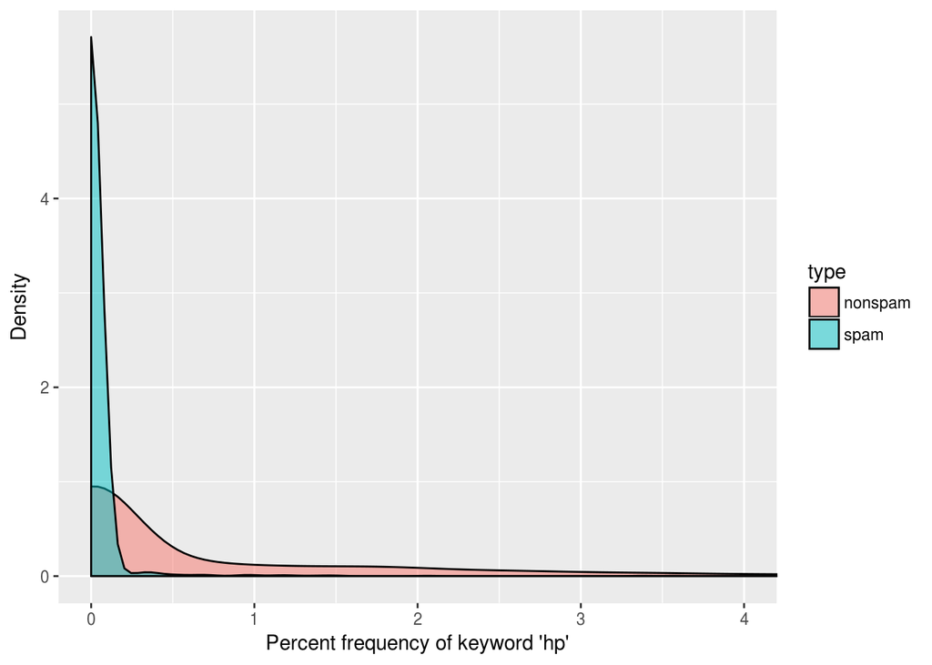

```r
spam %>% ggplot() +
  geom_density(aes(x = hp, group = type, fill = type), alpha = 0.5, adjust = 2) +
  coord_cartesian(xlim = c(0, 4)) + # ignore outliers
  xlab("Percent frequency of keyword 'hp'") +
  ylab("Density")
```

Yep, that’s a big difference! It seems the presence of the phrase ‘hp’ in an email could be used to indicate that it is not spam.

## Data Analysis

Ok, now let’s explore building a predictive model to classify emails as spam or non-spam.

### Split Data

First we’ll randomly set aside 10% of our dataset to act as a testing set, and we’ll use the other 90% to train the model.

```r
TEST_SIZE_PCT <- 0.1
ntest <- round(nrow(spam) * TEST_SIZE_PCT)

indices.test <- base::sample(1:nrow(spam), ntest, replace = FALSE)

spam.test <- spam[indices.test,]
spam.train <- spam[-indices.test,]

print(nrow(spam.test))
```

```
## [1] 460
```

```r
print(nrow(spam.train))
```

```
## [1] 4141
```

### Train model

Let’s keep it simple and train a logistic regression.

```r
# Fit the logistic regression, and look at p-values for significant features
model <- glm(type ~ ., data = spam.train, family = binomial)
summary(model)
```

```
##
## Call:
## glm(formula = type ~ ., family = binomial, data = spam.train)
##
## Deviance Residuals:
##     Min       1Q   Median       3Q      Max
## -4.1732  -0.1984   0.0000   0.1179   5.0831
##
## Coefficients:
##                     Estimate Std. Error z value Pr(>|z|)
## (Intercept)       -1.405e+00  1.453e-01  -9.670  < 2e-16 ***
## make              -3.302e-01  2.314e-01  -1.427 0.153575
## address           -1.556e-01  7.104e-02  -2.190 0.028490 *
## all                1.084e-01  1.149e-01   0.944 0.345385
## num3d              1.971e+00  1.435e+00   1.373 0.169651
## our                5.549e-01  1.101e-01   5.038 4.70e-07 ***
## over               8.604e-01  2.607e-01   3.300 0.000967 ***
## remove             2.286e+00  3.484e-01   6.561 5.33e-11 ***
## internet           5.479e-01  1.667e-01   3.286 0.001015 **
## order              5.686e-01  2.921e-01   1.947 0.051553 .
## mail               9.548e-02  7.054e-02   1.354 0.175890
## receive           -2.725e-01  3.179e-01  -0.857 0.391408
## will              -1.469e-01  7.929e-02  -1.853 0.063907 .
## people            -6.107e-02  2.470e-01  -0.247 0.804686
## report             5.944e-02  1.461e-01   0.407 0.684194
## addresses          1.054e+00  6.985e-01   1.509 0.131311
## free               1.032e+00  1.539e-01   6.705 2.02e-11 ***
## business           8.097e-01  2.281e-01   3.550 0.000386 ***
## email              1.091e-01  1.185e-01   0.921 0.356974
## you                7.088e-02  3.628e-02   1.954 0.050722 .
## credit             1.145e+00  5.807e-01   1.971 0.048742 *
## your               2.374e-01  5.528e-02   4.295 1.75e-05 ***
## font               2.201e-01  1.672e-01   1.316 0.188036
## num000             2.537e+00  5.779e-01   4.390 1.13e-05 ***
## money              3.660e-01  1.535e-01   2.385 0.017083 *
## hp                -1.836e+00  3.154e-01  -5.821 5.85e-09 ***
## hpl               -1.044e+00  4.523e-01  -2.307 0.021033 *
## george            -1.051e+01  2.197e+00  -4.783 1.73e-06 ***
## num650             3.918e-01  1.961e-01   1.999 0.045656 *
## lab               -2.537e+00  1.538e+00  -1.650 0.099025 .
```

[output cut: 23 more lines]

```
## charDollar         5.189e+00  7.482e-01   6.935 4.07e-12 ***
## charHash           2.041e+00  1.168e+00   1.747 0.080641 .
## capitalAve         1.217e-03  1.980e-02   0.061 0.950978
## capitalLong        9.575e-03  2.658e-03   3.603 0.000314 ***
## capitalTotal       7.617e-04  2.240e-04   3.400 0.000674 ***
## ---
## Signif. codes:  0 '***' 0.001 '**' 0.01 '*' 0.05 '.' 0.1 ' ' 1
##
## (Dispersion parameter for binomial family taken to be 1)
##
##     Null deviance: 5550.0  on 4140  degrees of freedom
## Residual deviance: 1648.2  on 4083  degrees of freedom
## AIC: 1764.2
##
## Number of Fisher Scoring iterations: 13
```

Ok, R makes that easy, and even conveniently let’s us check p-values for signifcant features of the model. Now let’s check how well this model fits the training data, first using a confusion matrix.

```r
# Use model to generate labels on training set
predict.train <- predict(model, type = 'response')

# Confusion matrix
table(spam.train$type, predict.train > 0.5)
```

```
##
##           FALSE TRUE
##   nonspam  2403  110
##   spam      173 1455
```

Not bad! Let’s also explicitly get an accuracy metric, between 0 and 100 percent.

```r
# Function which works on subsets of the spam dataset
compute_accuracy <- function(model, spam_subset) {

  # Run the model on the dataset, and interpret an output p > 0.5 as a
  # positive spam classification
  predicted_type <- predict(model, newdata = spam_subset, type='response')
  predicted_type <- ifelse(predicted_type > 0.5, "spam", "nonspam")

  # Calculate a metric for accuracy
  error <- mean(predicted_type != spam_subset$type)

  accuracy <- (1 - error) * 100
  accuracy <- signif(accuracy, digits = 3)

  return(accuracy)
}

# Run the function on the training data
print(sprintf("Accuracy: %.1f%%", compute_accuracy(model, spam.train)))
```

```
## [1] "Accuracy: 93.2%"
```

Looking pretty good, as we would expect since the model was fit to this training data.

### Test model

Now let’s see how well the model classifies the test set data, which it hasn’t seen before.

```r
test_accuracy <- compute_accuracy(model, spam.test)
print(sprintf("Accuracy: %.1f%%", test_accuracy))
```

```
## [1] "Accuracy: 93.7%"
```

The model uses the features in the test set to correctly classify email as spam 93.7% of the time. That seems fairly good!

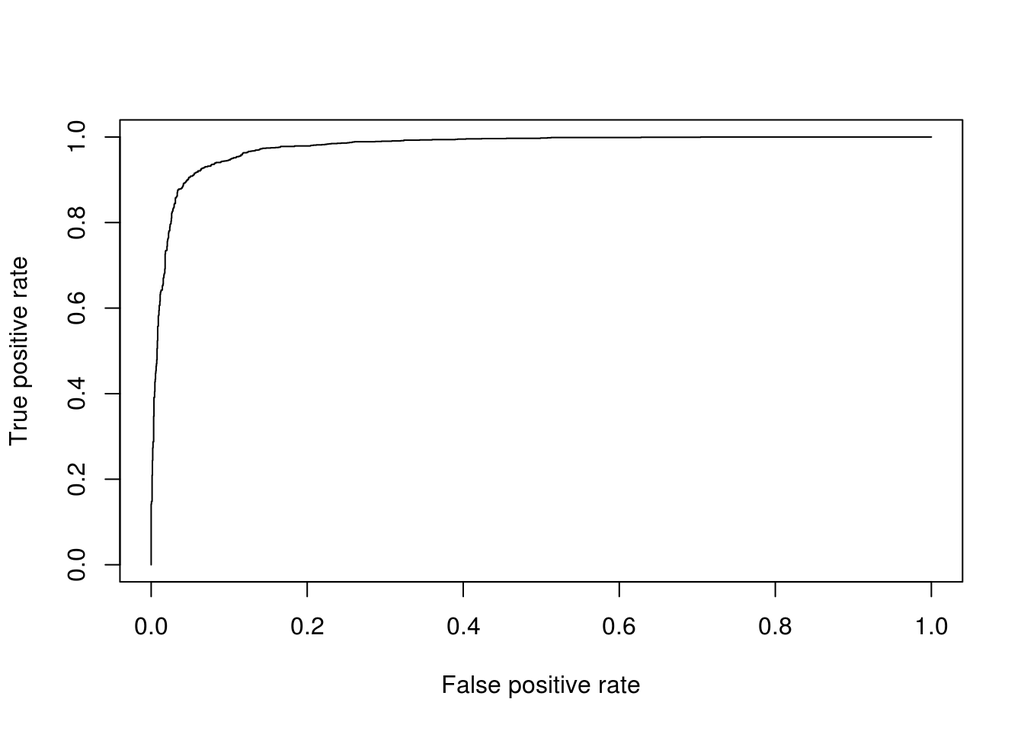

```r
# Use the model to classify the test data set
predict.test <- predict(model, type = 'response')

# Create an ROCR prediction object
pred <- prediction(predict.train, spam.train$type)

# Create an ROCR performance object
perf <- performance(pred, measure = 'tpr', x.measure = 'fpr')

# Plot the ROC curve
plot(perf)
```

This looks really good! We want the plot to hug the top-left corner. We can compute a useful statistic of how good our classifier is, using the area under the curve (AUC).

```r
auc <- performance(pred, measure = "auc")
auc <- auc@y.values[[1]]
print(auc)
```

```
## [1] 0.9770789
```

An AUC above .95 is considered very high. Our model’s AUC of 0.977 meets that requirement.

## Conclusion

Given our promising results, we may be tempted to deploy our model and call it a day. But we should keep in mind our model’s limits. Any model is only as good as its data, and several of the influential features in our sample are very specific (like ‘hp’ and ‘george’). Also, false positive classifications as spam are clearly very undesirable to an end user. So we may need to do more work to achieve an error rate less than 6.3%.